# Exploring Gapminder Dataset (HW2 - STAT 545)

Phuong (Sam) Can

24/09/2019

Let’s tackle each question in the assignment:

1.1 & 1.2. We have the output as below:

```r
# 1.1 & 1.2
gapminder %>%
  filter(country == sample(country, 3) & year > 1969 & year < 1980) %>%
  select(country, gdpPercap)
```

```
## # A tibble: 2 x 2
##   country gdpPercap
##   <fct>       <dbl>
## 1 Libya      21011.
## 2 Myanmar      371
```

1.3. We have the output as below:

```r
# 1.3
gapminder %>%
  group_by(country) %>%
  summarise(lifeExp_increase = (diff(lifeExp, lag = 11) > 0)) %>%
  filter(lifeExp_increase == TRUE)
```

```
## # A tibble: 140 x 2
##    country     lifeExp_increase
##    <fct>       <lgl>
##  1 Afghanistan TRUE
##  2 Albania     TRUE
##  3 Algeria     TRUE
##  4 Angola      TRUE
##  5 Argentina   TRUE
##  6 Australia   TRUE
##  7 Austria     TRUE
##  8 Bahrain     TRUE
##  9 Bangladesh  TRUE
## 10 Belgium     TRUE
## # … with 130 more rows
```

1.4. We have the output as below:

```r
# 1.4
gapminder %>%
  group_by(country) %>%
  summarise(max_gdpPercap = max(gdpPercap))
```

```
## # A tibble: 142 x 2
##    country     max_gdpPercap
##    <fct>               <dbl>
##  1 Afghanistan          978.
##  2 Albania             5937.
##  3 Algeria             6223.
##  4 Angola              5523.
##  5 Argentina          12779.
##  6 Australia          34435.
##  7 Austria            36126.
##  8 Bahrain            29796.
##  9 Bangladesh          1391.
## 10 Belgium            33693.
## # … with 132 more rows
```

1.5. We have the output as below:

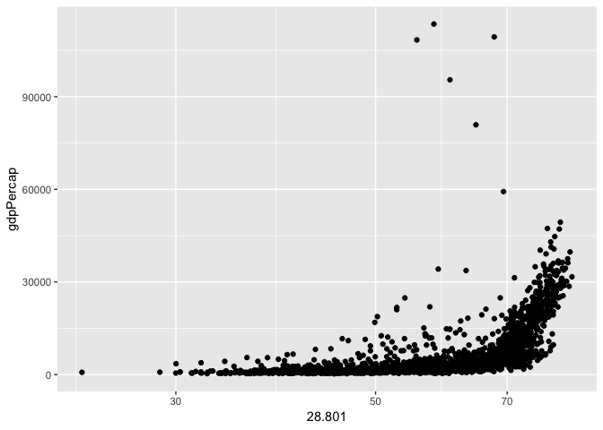

```r
# 1.5
ggplot(gapminder, aes(x=lifeExp, y=gdpPercap)) + geom_point() + scale_x_log10(lifeExp)
```

```r
options("scipen"=100, "digits"=4)
```

2. I selected two variables for exploration: *continent* (categorical) and *pop* (quantitative)
- *continent* has `5` levels, which are: `Africa, Americas, Asia, Europe, Oceania`.
- *pop* has a mean of `29601212.3245`, median of `7023595.5`, ranging from `60011` to `1318683096`, and has a standard deviation of `106157896.7439`. Here is a histogram to describe the distribution of the world population in the dataset.

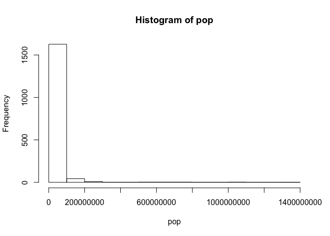

```r
hist(pop)
```

Here is a boxplot to describe the relationship between these two variables, where you can see the median, quantiles, and ranges of values for population in each continent.

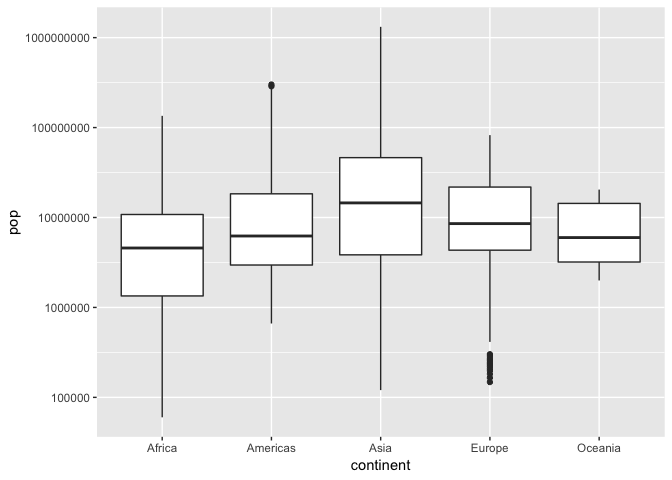

```r
ggplot(gapminder, aes(x=continent, y=pop)) + geom_boxplot() + scale_y_log10()
```

3. Explore various plot types:
1. A scatterplot with two quantitative variables: *lifeExp* and *gdpPercap.*

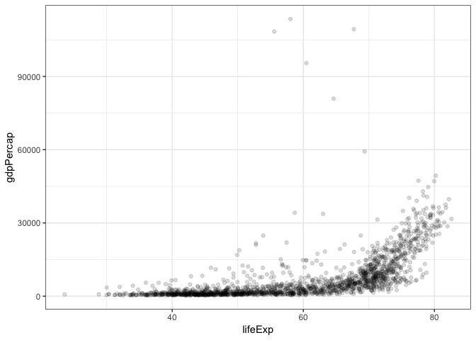

```r
ggplot(gapminder, aes(lifeExp, gdpPercap)) + geom_point(alpha = 0.15) + theme_bw()
```

2. A bar graph with one quantitative and one categorical variable:

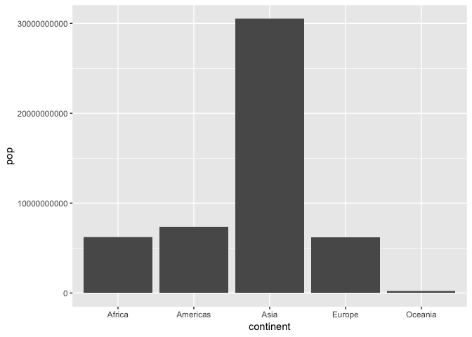

```r
ggplot(gapminder, aes(continent, pop)) + geom_col()
```

Extra 1. We have the output as below:

```r
filter(gapminder, country == c("Rwanda", "Afghanistan"))
```

```
## # A tibble: 12 x 6
##    country     continent  year lifeExp      pop gdpPercap
##    <fct>       <fct>     <int>   <dbl>    <int>     <dbl>
##  1 Afghanistan Asia       1957    30.3  9240934      821.
##  2 Afghanistan Asia       1967    34.0 11537966      836.
##  3 Afghanistan Asia       1977    38.4 14880372      786.
##  4 Afghanistan Asia       1987    40.8 13867957      852.
##  5 Afghanistan Asia       1997    41.8 22227415      635.
##  6 Afghanistan Asia       2007    43.8 31889923      975.
##  7 Rwanda      Africa     1952    40    2534927      493.
##  8 Rwanda      Africa     1962    43    3051242      597.
##  9 Rwanda      Africa     1972    44.6  3992121      591.
## 10 Rwanda      Africa     1982    46.2  5507565      882.
## 11 Rwanda      Africa     1992    23.6  7290203      737.
## 12 Rwanda      Africa     2002    43.4  7852401      786.
```

Extra 2. We have the output as below:

```r
knitr::kable(head(gapminder, 10))
```

| country | continent | year | lifeExp | pop | gdpPercap |
| --- | --- | --- | --- | --- | --- |
| Afghanistan | Asia | 1952 | 28.80 | 8425333 | 779.4 |
| Afghanistan | Asia | 1957 | 30.33 | 9240934 | 820.9 |
| Afghanistan | Asia | 1962 | 32.00 | 10267083 | 853.1 |
| Afghanistan | Asia | 1967 | 34.02 | 11537966 | 836.2 |
| Afghanistan | Asia | 1972 | 36.09 | 13079460 | 740.0 |
| Afghanistan | Asia | 1977 | 38.44 | 14880372 | 786.1 |
| Afghanistan | Asia | 1982 | 39.85 | 12881816 | 978.0 |
| Afghanistan | Asia | 1987 | 40.82 | 13867957 | 852.4 |
| Afghanistan | Asia | 1992 | 41.67 | 16317921 | 649.3 |
| Afghanistan | Asia | 1997 | 41.76 | 22227415 | 635.3 |

```r
DT::datatable(gapminder)
```

|  | country | continent | year | lifeExp | pop | gdpPercap |
| --- | --- | --- | --- | --- | --- | --- |
| 1 | Afghanistan | Asia | 1952 | 28.801 | 8425333 | 779.4453145 |
| 2 | Afghanistan | Asia | 1957 | 30.332 | 9240934 | 820.8530296 |
| 3 | Afghanistan | Asia | 1962 | 31.997 | 10267083 | 853.10071 |
| 4 | Afghanistan | Asia | 1967 | 34.02 | 11537966 | 836.1971382 |
| 5 | Afghanistan | Asia | 1972 | 36.088 | 13079460 | 739.9811058 |
| 6 | Afghanistan | Asia | 1977 | 38.438 | 14880372 | 786.11336 |
| 7 | Afghanistan | Asia | 1982 | 39.854 | 12881816 | 978.0114388 |
| 8 | Afghanistan | Asia | 1987 | 40.822 | 13867957 | 852.3959448 |
| 9 | Afghanistan | Asia | 1992 | 41.674 | 16317921 | 649.3413952 |
| 10 | Afghanistan | Asia | 1997 | 41.763 | 22227415 | 635.341351 |

[output cut: 1694 more lines]